# Bulk RNA-Seq Example

## 0.1 Bulk RNA-Seq Analysis with XYomics

Authors: Enrico Glaab and Sophie Le Bars

# 1 Introduction

This vignette demonstrates a standard workflow for analyzing bulk RNA-seq data to identify sex-specific effects using the **XYomics** package. The package provides a streamlined set of tools for differential expression, pathway analysis, and network-based interpretation.

# 2 Data Simulation

We begin by simulating a bulk RNA-seq dataset to illustrate the package’s capabilities. The `simulate_omics_data` function creates a dataset with 500 genes and 100 samples, balanced across phenotype (Control/Disease) and sex (male/female).

The simulation introduces three types of effects: - **Male-specific:** Genes up-regulated in the disease state only in males. - **Female-specific:** Genes up-regulated in the disease state only in females. - **Sex-dimorphic:** Genes regulated in opposite directions between males and females in the disease state.

```r
library(XYomics)
library(dplyr)
library(clusterProfiler)
library(org.Hs.eg.db)

simulate_omics_data <- function(n_samples = 100, n_genes = 500) {
  set.seed(123)
  all_entrez <- keys(org.Hs.eg.db, keytype = "ENTREZID")
  selected_entrez <- sample(all_entrez, n_genes)

  sex <- rep(c("m", "f"), each = n_samples / 2)
  phenotype <- rep(rep(c("Control", "Disease"), each = n_samples / 4), 2)

  expression_data <- matrix(rnorm(n_samples * n_genes, mean = 10, sd = 0.1),
                            nrow = n_genes, ncol = n_samples)

  male_disease <- which(sex == "m" & phenotype == "Disease")
  female_disease <- which(sex == "f" & phenotype == "Disease")

  expression_data[1:25, male_disease] <- expression_data[1:25, male_disease] + 8
  expression_data[26:50, female_disease] <- expression_data[26:50, female_disease] + 8
  expression_data[51:75, male_disease] <- expression_data[51:75, male_disease] + 6
  expression_data[51:75, female_disease] <- expression_data[51:75, female_disease] - 6

  colnames(expression_data) <- paste0("Sample", 1:n_samples)
  rownames(expression_data) <- selected_entrez

  return(list(expression_data = expression_data, phenotype = phenotype, sex = sex))
}

simulated_data <- simulate_omics_data()
omics_data <- simulated_data$expression_data
phenotype <- simulated_data$phenotype
sex <- simulated_data$sex

cat("Dimensions of expression data:", dim(omics_data), "\n")
```

```
## Dimensions of expression data: 500 100
```

# 3 Differential Expression Analysis Strategies

When analyzing sex differences, researchers must be aware of the pitfalls of associated statistical analyses, including the limitations of sex-stratified analyses and the challenges of analyzing interactions between sex and disease state.

**Sex-stratified analyses** use standard statistical tests for differential molecular abundance analysis to test for disease-associated changes in each sex separately. These may include classical parametric hypothesis tests, such as Welch’s test for normally distributed data, or non-parametric tests, such as the Mann–Whitney U test, as well as special moderated statistics for high-dimensional omics data analysis, such as the empirical Bayes moderated t-statistic. However, a pure sex-stratified analysis may misclassify a change as sex-specific if it uses a standard significance threshold to assess both the presence and absence of an effect. Stochastic variation in significance scores around a chosen threshold may lead to the erroneous detection of significance specific to only one sex, especially if the p-value in the other sex marginally exceeds the chosen threshold. In addition, such an analysis may miss sex-modulated changes, where significant changes in both sexes share the same direction but differ significantly in magnitude; these changes require cross-sex comparisons for accurate detection.

**Interaction analysis** (using a multiplicative term like `sex*disease`) formally tests whether the relationship between disease and molecular changes differs significantly between males and females. Not only can such interaction terms reveal complexities in disease mechanisms that might otherwise be obscured in analyses that do not consider SABV, but they also have the potential to detect changes that are limited to the magnitude of an effect, an aspect that sex-stratified analyses do not capture. Nevertheless, robust estimation of interaction effects requires large sample sizes, which are often not available due to the costs associated with advanced molecular profiling techniques such as single-cell RNA sequencing.

## 3.1 Method 1: Sex-Stratified Analysis

Here, we use the `sex_stratified_analysis_bulk` function to perform a stratified analysis.

```r
male_deg <- sex_stratified_analysis_bulk(
  x = omics_data,
  phenotype = phenotype,
  gender = sex,
  analysis_type = "male"
)

female_deg <- sex_stratified_analysis_bulk(
  x = omics_data,
  phenotype = phenotype,
  gender = sex,
  analysis_type = "female"
)

cat("Top differentially expressed genes in males (stratified analysis):\n")
```

```
## Top differentially expressed genes in males (stratified analysis):
```

```r
print(head(male_deg))
```

```
##              logFC  AveExpr        t P.Value adj.P.Val        B
## 124900609 8.078211 13.98250 285.3067       0         0 5530.402
## 127896748 8.031050 14.00357 284.4926       0         0 5520.917
## 127891734 8.003977 14.02736 283.4291       0         0 5508.488
## 127402385 8.022368 14.00286 283.3256       0         0 5507.276
## 127830600 8.018576 14.00111 283.3203       0         0 5507.214
## 129993743 7.997612 14.00713 283.0152       0         0 5503.639
```

## 3.2 Method 2: Interaction Term Analysis

We use the `sex_interaction_analysis_bulk` function to perform a formal interaction analysis using a multiplicative term.

```r
interaction_term_results_bulk <- sex_interaction_analysis_bulk(
  x = omics_data,
  phenotype = phenotype,
  gender = sex,
  phenotype_labels = c("Control", "Disease"),
  sex_labels = c("f", "m")
)

cat("Top genes from Interaction Term analysis (bulk):\n")
```

```
## Top genes from Interaction Term analysis (bulk):
```

```r
print(head(interaction_term_results_bulk))
```

```
##              logFC  AveExpr        t P.Value adj.P.Val        B
## 130060506 8.026858 11.99883 200.3543       0         0 20059.71
## 130066717 8.045758 11.99960 200.8261       0         0 20154.33
## 127891734 8.040629 12.00748 200.6980       0         0 20128.63
## 127830113 7.961523 12.00532 198.7235       0         0 19734.34
## 129993743 8.003568 12.01005 199.7730       0         0 19943.42
## 127408622 7.996061 12.00467 199.5856       0         0 19906.01
```

# 4 Identification of Sex-Specific Genes (from Stratified Analysis)

The `identify_sex_specific_genes` function categorizes genes based on the results of the **stratified analysis**. This provides a useful, albeit potentially less robust, classification.

```r
sex_specific_results <- identify_sex_specific_genes(
  male_results = male_deg,
  female_results = female_deg,
  target_fdr = 0.05,
  exclude_fdr = 0.5
)

cat("Number of genes in each category (from stratified analysis):\n")
```

```
## Number of genes in each category (from stratified analysis):
```

```r
print(table(sex_specific_results$gene_type))
```

```
##
## female-specific   male-specific   sex-dimorphic
##              26              28              25
```

# 5 Visualization of Expression Patterns

We use `generate_boxplot` to visualize the expression of top genes identified by the stratified analysis.

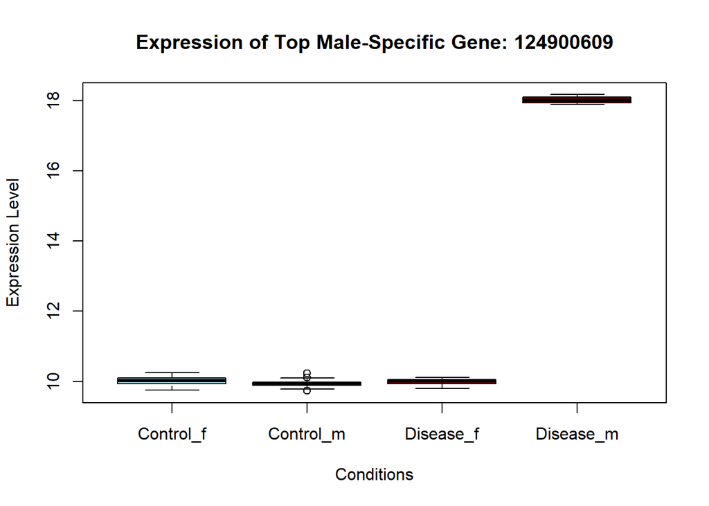

```r
# Male-specific gene
top_male_gene <- sex_specific_results %>%
  filter(gene_type == "male-specific") %>%
  arrange(male_FDR) %>%
  pull(gene_id) %>%
  head(1)

generate_boxplot(
  x = omics_data,
  index = top_male_gene,
  phenotype = phenotype,
  gender = sex,
  title = paste("Expression of Top Male-Specific Gene:", top_male_gene)
)
```

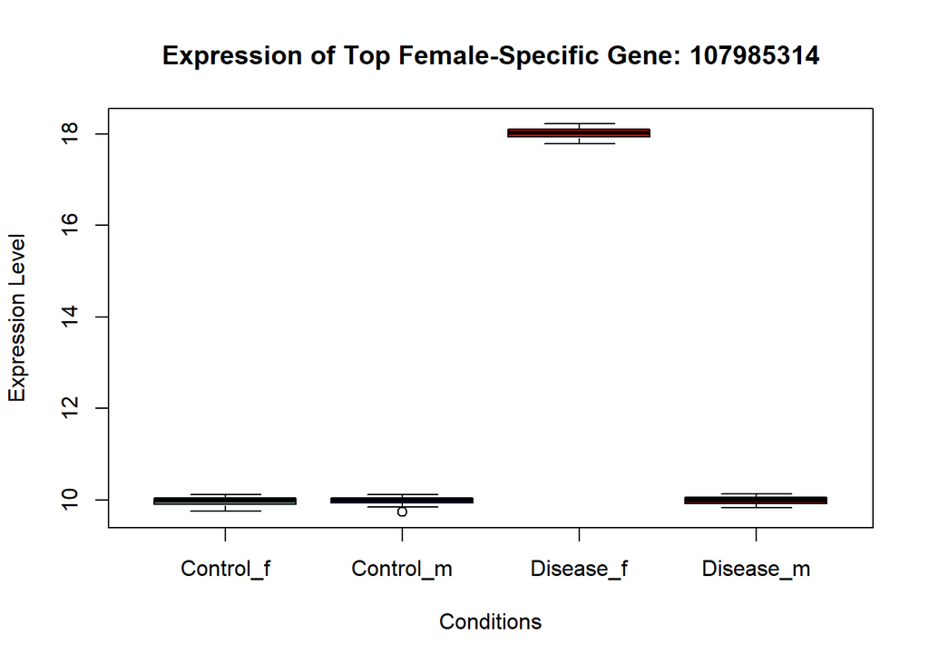

```r
# Female-specific gene
top_female_gene <- sex_specific_results %>%
  filter(gene_type == "female-specific") %>%
  arrange(female_FDR) %>%
  pull(gene_id) %>%
  head(1)

generate_boxplot(
  x = omics_data,
  index = top_female_gene,
  phenotype = phenotype,
  gender = sex,
  title = paste("Expression of Top Female-Specific Gene:", top_female_gene)
)
```

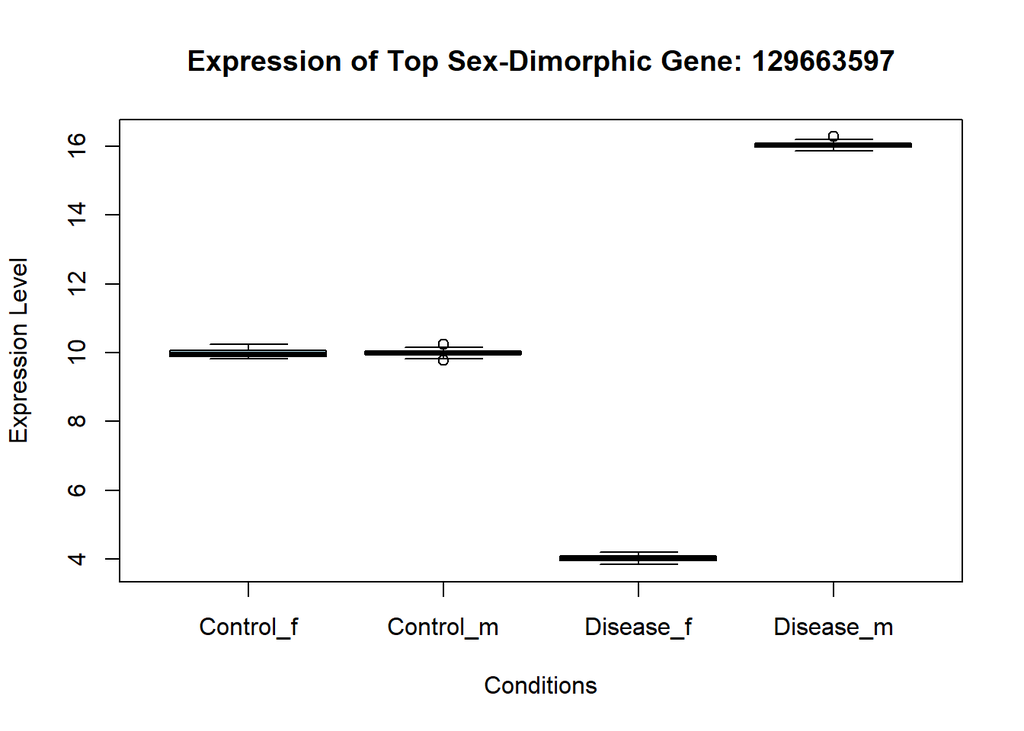

```r
# Sex-dimorphic gene
top_dimorphic_gene <- sex_specific_results %>%
  filter(gene_type == "sex-dimorphic") %>%
  arrange(male_FDR) %>%
  pull(gene_id) %>%
  head(1)

generate_boxplot(
  x = omics_data,
  index = top_dimorphic_gene,
  phenotype = phenotype,
  gender = sex,
  title = paste("Expression of Top Sex-Dimorphic Gene:", top_dimorphic_gene)
)
```

# 6 Pathway Enrichment Analysis

We perform pathway enrichment on the gene lists derived from the stratified analysis.

```r
# GO analysis for female-specific genes
female_specific_genes <- sex_specific_results %>%
  filter(gene_type == "female-specific") %>%
  pull(gene_id)

cat("\nPerforming GO enrichment analysis for female-specific genes...\n")
```

```
##
## Performing GO enrichment analysis for female-specific genes...
```

```r
go_results <- improved_pathway_enrichment(
  gene_list = female_specific_genes,
  enrichment_db = "GO"
)
if (!is.null(go_results) && nrow(go_results) > 0) {
  cat("Top GO Terms:\n")
  print(head(as.data.frame(go_results)))
} else {
  cat("No significant GO terms found.\n")
}
```

```
## Top GO Terms:
##            ONTOLOGY         ID                                  Description
## GO:0051643       BP GO:0051643           endoplasmic reticulum localization
## GO:0120009       BP GO:0120009                 intermembrane lipid transfer
## GO:0140056       BP GO:0140056 organelle localization by membrane tethering
## GO:0022406       BP GO:0022406                             membrane docking
## GO:0007029       BP GO:0007029           endoplasmic reticulum organization
## GO:0015914       BP GO:0015914                       phospholipid transport
##            GeneRatio   BgRatio       pvalue    p.adjust qvalue geneID Count
## GO:0051643       1/1  10/18870 0.0005299417 0.004239534     NA  23344     1
## GO:0120009       1/1  54/18870 0.0028616852 0.007277866     NA  23344     1
## GO:0140056       1/1  82/18870 0.0043455220 0.007277866     NA  23344     1
## GO:0022406       1/1  92/18870 0.0048754637 0.007277866     NA  23344     1
## GO:0007029       1/1 100/18870 0.0052994171 0.007277866     NA  23344     1
## GO:0015914       1/1 103/18870 0.0054583996 0.007277866     NA  23344     1
```

```r
# GO analysis for male-specific genes
male_specific_genes <- sex_specific_results %>%
  filter(gene_type == "male-specific") %>%
  pull(gene_id)

cat("\nPerforming GO pathway analysis for male-specific genes...\n")
```

```
##
## Performing GO pathway analysis for male-specific genes...
```

```r
go_results_male <- improved_pathway_enrichment(
  gene_list = male_specific_genes,
  enrichment_db = "GO"
)
if (!is.null(go_results_male) && nrow(go_results_male) > 0) {
  cat("Top GO Pathways:\n")
  print(head(as.data.frame(go_results_male)))
} else {
  cat("No significant GO pathways found.\n")
}
```

```
## No significant GO pathways found.
```

# 7 Protein-protein Interaction Network Analysis

Finally, we construct a protein-protein interaction network using the results from the stratified analysis.

### 7.0.1 1. Fetching the STRING Network

First, we download and process a human protein-protein interaction network from the STRING database using `get_string_network`. As this step can be time-consuming, for this vignette we will create a small dummy network for demonstration purposes.

```r
# In a real analysis, you would run:
# string_network <- get_string_network(organism = "9606", score_threshold = 700)

# For this vignette, we create a small dummy network
set.seed(123)
dummy_nodes <- unique(c(male_specific_genes, female_specific_genes))
if(length(dummy_nodes) > 100) dummy_nodes <- sample(dummy_nodes, 100)
dummy_edges <- data.frame(
  from = sample(dummy_nodes, 50, replace = TRUE),
  to = sample(dummy_nodes, 50, replace = TRUE)
)
string_network <- igraph::graph_from_data_frame(dummy_edges, directed = FALSE)
string_network <- igraph::simplify(string_network)
cat("Using a dummy network for demonstration purposes.\n")
```

```
## Using a dummy network for demonstration purposes.
```

### 7.0.2 2. Constructing the PCSF Network

Next, we define “prizes” for our genes based on their statistical significance (e.g., -log10 of the p-value) and use the `construct_ppi_pcsf` function to build a context-specific network.

```r
# Use male DE results to define prizes
prizes <- -log10(male_deg$P.Value)
names(prizes) <- rownames(male_deg)
prizes <- prizes[is.finite(prizes)]

# Construct the network
ppi <- construct_ppi_pcsf(
  g = string_network,
  prizes = prizes,
  w = 2,
  b = 1,
  mu = 5e-04
)
```

```
##   100% of your terminal nodes are included in the interactome
```

```
##   Solving the PCSF...
```

```r
cat("Constructed PPI with", igraph::vcount(ppi), "nodes and", igraph::ecount(ppi), "edges.\n")
```

```
## Constructed PPI with 2 nodes and 1 edges.
```

### 7.0.3 3. Visualizing the Network

Finally, we use the `visualize_network` function to plot the resulting protein-protein interaction network. The node colors can represent different properties, such as the relative expression changes in males versus females.

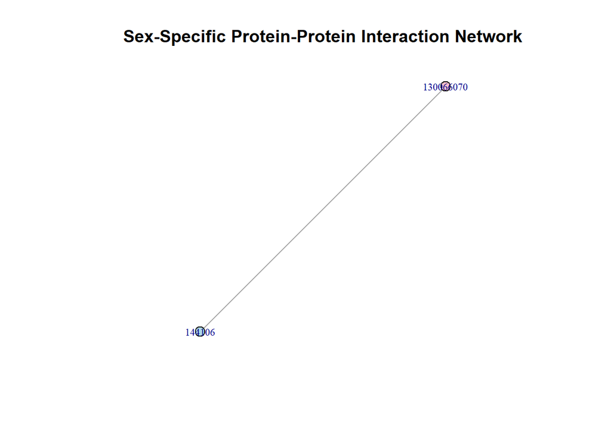

```
## IGRAPH e2c6aef UNWB 2 1 --
## + attr: name (v/c), prize (v/n), type (v/c), weight (e/n)
## + edge from e2c6aef (vertex names):
## [1] 130066070--144106
```

```r
visualize_network(
  g = ppi,
  female_res = female_deg,
  male_res = male_deg,
  vertex.size = 8,
  vertex.label.cex = 0.7,
  main = "Sex-Specific Protein-Protein Interaction Network"
)
```

# 8 Conclusion

This vignette has demonstrated two key approaches for analyzing sex-specific effects in bulk RNA-seq data. While sex-stratified analysis is a common first step, **interaction analysis provides a more statistically robust method** for identifying genes whose regulation by disease is truly dependent on sex. We recommend using an interaction-based approach where possible, while being mindful of the need for adequate sample sizes.